ASSIGNMENT -1

Rahul Pandey

```r
#Importing required libraries
library(nycflights13)
library(dplyr)
library(fivethirtyeight)
library(ggplot2)
```

Part A #q1

```r
testdf <- data.frame(
  row.names=c("Jack", "Rosa", "Dawn", "Vicki", "Blake", "Guillermo"),
  age=c(24, 23, NA, 25, 32, 19),
  city=c("Harlem", NA, "Queens", "Brooklyn", "Brooklyn", NA),
  gpa=c(3.5, 3.6, 4.0, NA, 3.8, NA))


count_na <- function (testdf,byrow=TRUE)
{
  if(byrow==FALSE)
    colSums(is.na(testdf))
  else
    rowSums(is.na(testdf))
}
count_na(testdf,TRUE) #passing true to get rowwise na count
```

```
##      Jack      Rosa      Dawn     Vicki     Blake Guillermo
##         0         1         1         1         0         2
```

```r
count_na(testdf,FALSE) #passing false to get column wise
```

```
##  age city  gpa
##    1    2    2
```

#q2

```r
testdf <- data.frame(
  row.names=c("Jack", "Rosa", "Dawn", "Vicki", "Blake", "Guillermo"),
  age=c(24, 23, NA, 25, 32, 19),
  city=c("Harlem", NA, "Queens", "Brooklyn", "Brooklyn", NA),
  gpa=c(3.5, 3.6, 4.0, NA, 3.8, NA))

my_mode <- function(x) {              # Create mode function
  x <- na.omit(x)
  unique_x <- unique(x)
  tabulate_x <- tabulate(match(x, unique_x))
  unique_x[tabulate_x == max(tabulate_x)]

}



imputedf <- function(testdf,usemean=FALSE)
{
  y <- colnames(select_if(testdf,is.numeric))  #assigning columns
  z <- colnames(select_if(testdf, is.factor))
  z <- append(z, colnames(select_if(testdf, is.character)))
  if(usemean==TRUE)
  {
    for(i in y)
    {              #calculating mean
      testdf[is.na(testdf[,i]), i] <- mean(testdf[,i], na.rm = TRUE)
    }
  }

  else
  {
    for(i in y)
      #calculating median
    {
      testdf[is.na(testdf[,i]), i] <- median(testdf[,i], na.rm = TRUE)
    }
  }
  for(i in z)
  {              #calculating mode
    testdf[is.na(testdf[,i]), i] <- my_mode(testdf[,c(z)])
  }


  return(testdf)
}
imputedf(testdf,TRUE) #true for mean
```

```
##            age     city   gpa
## Jack      24.0   Harlem 3.500
## Rosa      23.0 Brooklyn 3.600
## Dawn      24.6   Queens 4.000
## Vicki     25.0 Brooklyn 3.725
## Blake     32.0 Brooklyn 3.800
## Guillermo 19.0 Brooklyn 3.725
```

```r
imputedf(testdf,FALSE) # false for median
```

[output not shown]

Part B

#q3

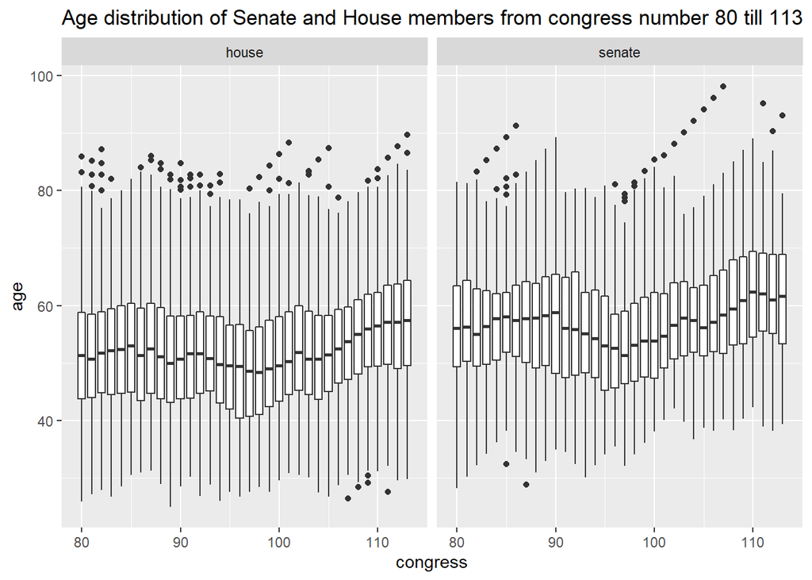

```r
ggplot(congress_age,aes(x=congress,y=age,group=congress)) + geom_boxplot()+facet_grid(~chamber)+
labs(title=
"Age distribution of Senate and House members from congress number 80 till 113" )
```

Insights

2.)Senate’s median age was always greater than house’s median age.

#q4

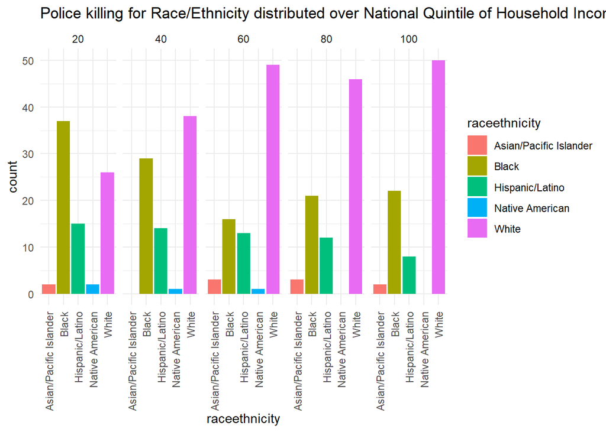

```r
police_killing_a <- na.omit(police_killings) #removing na
police_killing_a$h_quintile <- ntile(police_killing_a$h_income,5)#calculating quintiles
police_killing_a$h_quintile <- police_killing_a$h_quintile*20

ggplot(police_killing_a,aes(x=raceethnicity,fill=raceethnicity))+ geom_bar() + facet_grid(~h_quintile) +
theme_minimal() +
theme(axis.text.x = element_text(angle = 90, vjust = 0.5, hjust=1))+
labs(title=
"Police killing for Race/Ethnicity distributed over National Quintile of Household Income" )
```

Insights

1.) In black population the police killing reduces as we increase the household income with a slight increase from 60th percentile to 80th percentile where as in white population the relation is inverse, which means, that the police killing increases as we increase the household income.

2.)For Hispanic the killings seems to be same across the home income percentiles with a little dip as we go higher up in the household income.

3.)Asian/pacific islander and Native Americans have the least killings according to the data with almost zero kills for asians in 20-4oth percentile and same for Native Americans is true in 60-100th percentile.

#q5

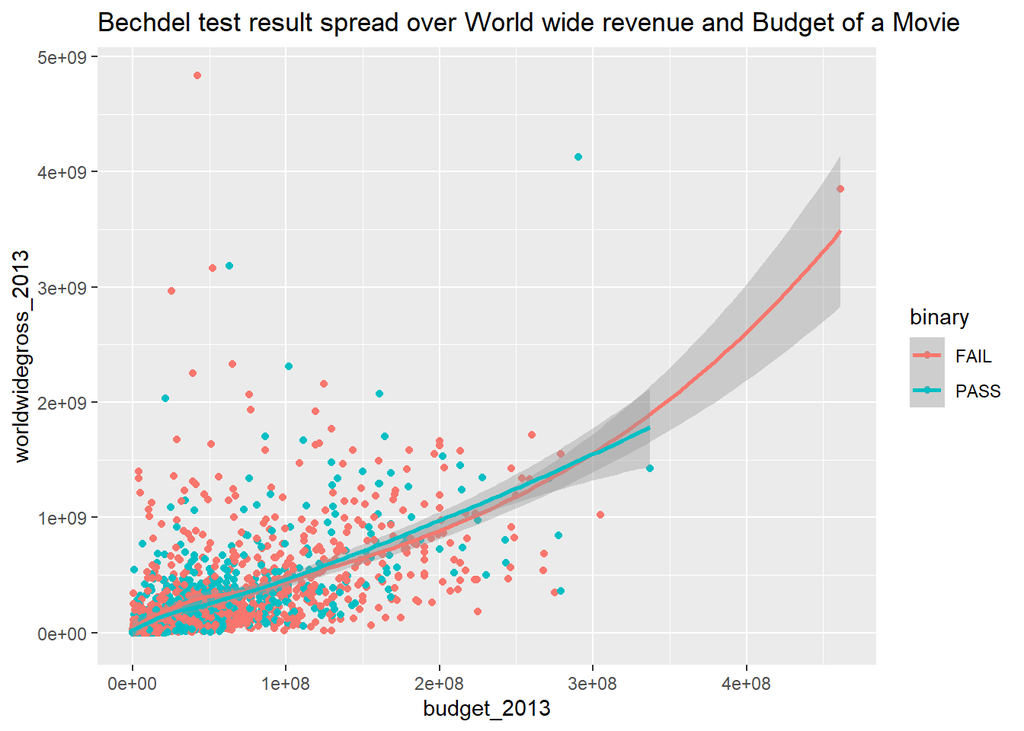

```r
bechdel$worldwidegross_2013 <-bechdel$intgross_2013+bechdel$domgross_2013
ggplot(bechdel,aes(x=budget_2013,y=worldwidegross_2013,color=binary))+ geom_point()+geom_smooth()+
  labs(title=
"Bechdel test result spread over World wide revenue and Budget of a Movie" )
```

Insights

1.)The movie’s budget and movie gross earning seems to have a positive linear relationships with some outlier present.So higher budget movie will generate more money on the box office.

2.)It is clear from the visualization that movie, right from the lower budget ones to higher ones , for both test results(pass and fail), have almost the same trend.

3.)There is a significant overlap of trendlines for both the test results.